# report4

Viktoria Zruttova

2024-04-07

```r
library(car)
library(caret)
```

```r
library(ggplot2)
library(dplyr)
library(GGally)
library(readxl)
library(MLmetrics)
#load the dataset
mydata <- read.csv('./data/day.csv')
```

```r
#convert 'dteday' column to Date format
mydata$dteday <- as.Date(mydata$dteday)

#season
mydata$season <- cut(mydata$season,
                     breaks = c(0.5, 1.5, 2.5, 3.5, 4.5),
                     labels = c("Winter", "Spring", "Summer", "Fall"))
mydata$season <- factor(mydata$season, levels = c("Winter", "Spring", "Summer", "Fall"))

#workingday
mydata$workingday <- ifelse(mydata$workingday == 0, "Not_Workingday", "Workingday")
mydata$workingday <- factor(mydata$workingday, levels = c("Not_Workingday", "Workingday"))

#weather
mydata$weathersit <- cut(mydata$weathersit,
                         breaks = c(0.5, 1.5, 2.5, 3.5, 4.5),
                         labels = c("Weather_1", "Weather_2", "Weather_3", "Weather_4"))
mydata$weathersit <- factor(mydata$weathersit, levels = c("Weather_1", "Weather_2", "Weather_3", "Weather_4"))

head(mydata)
```

```
##   instant     dteday season yr mnth holiday weekday     workingday weathersit
## 1       1 2011-01-01 Winter  0    1       0       6 Not_Workingday  Weather_2
## 2       2 2011-01-02 Winter  0    1       0       0 Not_Workingday  Weather_2
## 3       3 2011-01-03 Winter  0    1       0       1     Workingday  Weather_1
## 4       4 2011-01-04 Winter  0    1       0       2     Workingday  Weather_1
## 5       5 2011-01-05 Winter  0    1       0       3     Workingday  Weather_1
## 6       6 2011-01-06 Winter  0    1       0       4     Workingday  Weather_1
##       temp    atemp      hum windspeed casual registered  cnt
## 1 0.344167 0.363625 0.805833 0.1604460    331        654  985
## 2 0.363478 0.353739 0.696087 0.2485390    131        670  801
## 3 0.196364 0.189405 0.437273 0.2483090    120       1229 1349
## 4 0.200000 0.212122 0.590435 0.1602960    108       1454 1562
## 5 0.226957 0.229270 0.436957 0.1869000     82       1518 1600
## 6 0.204348 0.233209 0.518261 0.0895652     88       1518 1606
```

```r
#split the dataset into training and validation sets
training_data <- mydata[mydata$yr == 0, ]
validation_data <- mydata[mydata$yr == 1, ]
```

```r
# Set a seed for reproducibility
# Setting a seed is crucial for reproducibility and consistency of results.
# It ensures that when you run the same code multiple times, you'll ...
# ... obtain the same results.
set.seed(20231103)

# Filter dataset for year 2011 (0) and year 2012 (1)
year2011 <- mydata[mydata$yr == 0, ]
year2012 <- mydata[mydata$yr == 1, ]

# Add 'Type' column and assign values
year2011$Type <- "Training"
year2012$Type <- "Validation"

# Combine training and validation data
mydata <- rbind(year2011, year2012)
```

## Boxplots for proposed covariates y

We choose 3 questions of interest:

1. **How does working day affect the number of registered users?** where Y is the numnber of registered users
2. **How does season affect the number of casual users?** where Y is the sqrt(casual users)
3. **Is weather correlated to the number of bike rentals?*** where Y is the count of bikes rented

### NOTE - we probably need to do stratified sampling as in lab 9 comment, since we do not have equal representation in both training and validation datasets. We should address this issue - look into this further.

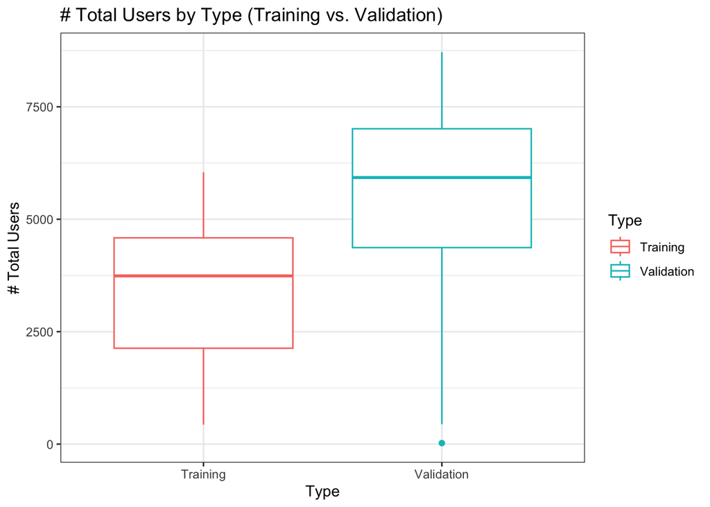

```r
#cnt
ggplot(mydata, aes(x = Type, y = cnt, color = Type)) +
  geom_boxplot(position = position_dodge(width = 0.8)) +
  labs(x = "Type", y = "# Total Users") +
  scale_fill_manual(name = "Dataset Type", values = c("Training" = "blue", "Validation" = "red")) +
  ggtitle("# Total Users by Type (Training vs. Validation)") +
  theme_bw()
```

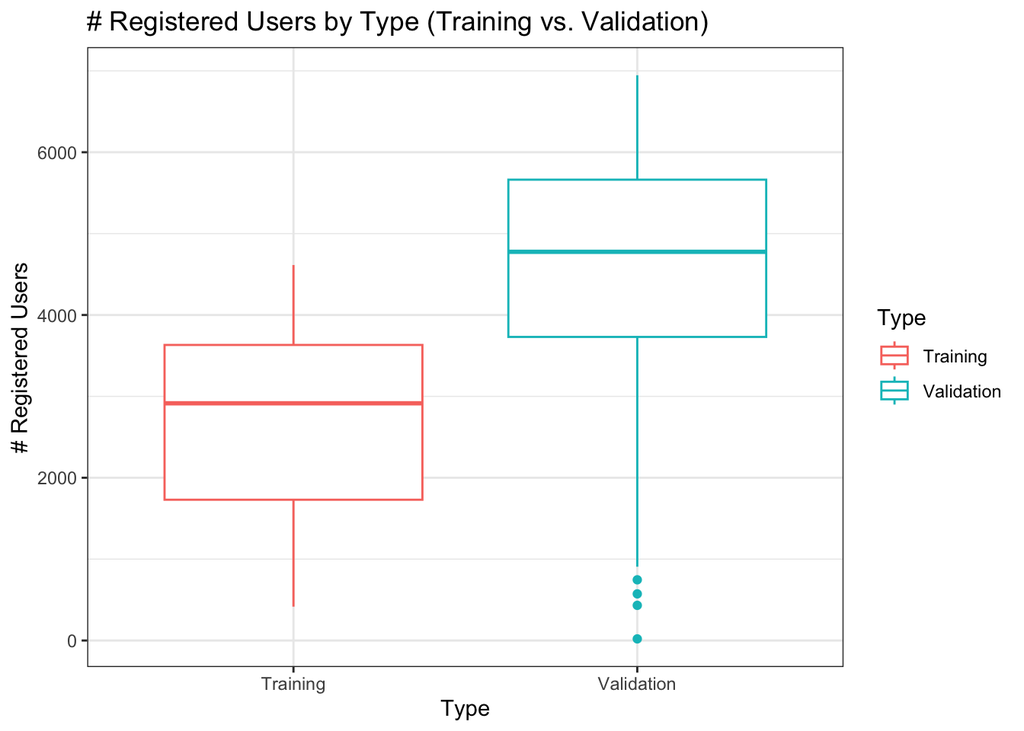

```r
#registered
ggplot(mydata, aes(x = Type, y = registered, color = Type)) +
  geom_boxplot(position = position_dodge(width = 0.8)) +
  labs(x = "Type", y = "# Registered Users") +
  scale_fill_manual(name = "Dataset Type", values = c("Training" = "blue", "Validation" = "red")) +
  ggtitle("# Registered Users by Type (Training vs. Validation)") +
  theme_bw()
```

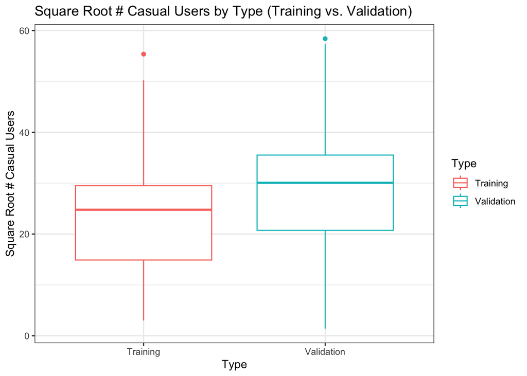

```r
#sqrt(casual)
ggplot(mydata, aes(x = Type, y = sqrt(casual), color = Type)) +
  geom_boxplot(position = position_dodge(width = 0.8)) +
  labs(x = "Type", y = "Square Root # Casual Users") +
  scale_fill_manual(name = "Dataset Type", values = c("Training" = "blue", "Validation" = "red")) +
  ggtitle("Square Root # Casual Users by Type (Training vs. Validation)") +
  theme_bw()
```

```r
#creating training data our of mydata (training -> data from 2011)
training_data <- subset(mydata, Type == "Training")
summary(training_data)
```

```
##     instant        dteday              season         yr         mnth
##  Min.   :  1   Min.   :2011-01-01   Winter:90   Min.   :0   Min.   : 1.000
##  1st Qu.: 92   1st Qu.:2011-04-02   Spring:92   1st Qu.:0   1st Qu.: 4.000
##  Median :183   Median :2011-07-02   Summer:94   Median :0   Median : 7.000
##  Mean   :183   Mean   :2011-07-02   Fall  :89   Mean   :0   Mean   : 6.526
##  3rd Qu.:274   3rd Qu.:2011-10-01               3rd Qu.:0   3rd Qu.:10.000
##  Max.   :365   Max.   :2011-12-31               Max.   :0   Max.   :12.000
##     holiday          weekday               workingday      weathersit
##  Min.   :0.0000   Min.   :0.000   Not_Workingday:115   Weather_1:226
##  1st Qu.:0.0000   1st Qu.:1.000   Workingday    :250   Weather_2:124
##  Median :0.0000   Median :3.000                        Weather_3: 15
##  Mean   :0.0274   Mean   :3.008                        Weather_4:  0
##  3rd Qu.:0.0000   3rd Qu.:5.000
##  Max.   :1.0000   Max.   :6.000
##       temp             atemp              hum           windspeed
##  Min.   :0.05913   Min.   :0.07907   Min.   :0.0000   Min.   :0.02239
##  1st Qu.:0.32500   1st Qu.:0.32195   1st Qu.:0.5383   1st Qu.:0.13558
##  Median :0.47917   Median :0.47285   Median :0.6475   Median :0.18690
##  Mean   :0.48666   Mean   :0.46684   Mean   :0.6437   Mean   :0.19140
##  3rd Qu.:0.65667   3rd Qu.:0.61238   3rd Qu.:0.7421   3rd Qu.:0.23508
##  Max.   :0.84917   Max.   :0.84090   Max.   :0.9725   Max.   :0.50746
##      casual         registered        cnt           Type
##  Min.   :   9.0   Min.   : 416   Min.   : 431   Length:365
##  1st Qu.: 222.0   1st Qu.:1730   1st Qu.:2132   Class :character
##  Median : 614.0   Median :2915   Median :3740   Mode  :character
##  Mean   : 677.4   Mean   :2728   Mean   :3406
##  3rd Qu.: 871.0   3rd Qu.:3632   3rd Qu.:4586
##  Max.   :3065.0   Max.   :4614   Max.   :6043
```

## Full models for each question

We are fitting full model which will be used to stepwise regression later. We address multicollinearity issue and delete variables that might cause it.

### Note: I am not sure which of the variables should be deleted and which should be kept in the model to make it better.

```r
full_model1 <- lm(registered ~ workingday + weathersit,
                 data = training_data)

full_model2 <- lm( sqrt(casual)~ workingday + season + weathersit,
                 data = training_data)

full_model3 <- lm( cnt ~ workingday+ temp + hum + windspeed + weathersit,
                 data = training_data)

summary(full_model1)
```

```
##
## Call:
## lm(formula = registered ~ workingday + weathersit, data = training_data)
##
## Residuals:
##     Min      1Q  Median      3Q     Max
## -2770.6  -940.7   358.4   732.7  1680.3
##
## Coefficients:
##                      Estimate Std. Error t value Pr(>|t|)
## (Intercept)           2396.97      94.59  25.339  < 2e-16 ***
## workingdayWorkingday   789.66     107.99   7.312 1.71e-12 ***
## weathersitWeather_2   -430.29     106.76  -4.031 6.79e-05 ***
## weathersitWeather_3  -1540.07     255.03  -6.039 3.86e-09 ***
## ---
## Signif. codes:  0 '***' 0.001 '**' 0.01 '*' 0.05 '.' 0.1 ' ' 1
##
## Residual standard error: 952.5 on 361 degrees of freedom
## Multiple R-squared:  0.1994, Adjusted R-squared:  0.1927
## F-statistic: 29.97 on 3 and 361 DF,  p-value: < 2.2e-16
```

```r
summary(full_model2)
```

```
##
## Call:
## lm(formula = sqrt(casual) ~ workingday + season + weathersit,
##     data = training_data)
##
## Residuals:
##      Min       1Q   Median       3Q      Max
## -20.9963  -3.5717   0.0082   3.6853  19.3328
##
## Coefficients:
##                      Estimate Std. Error t value Pr(>|t|)
## (Intercept)           22.5236     0.7917  28.449  < 2e-16 ***
## workingdayWorkingday -10.6997     0.6697 -15.977  < 2e-16 ***
## seasonSpring          14.3744     0.8760  16.409  < 2e-16 ***
## seasonSummer          17.1367     0.8728  19.633  < 2e-16 ***
## seasonFall             9.4982     0.8887  10.688  < 2e-16 ***
## weathersitWeather_2   -3.6307     0.6656  -5.455 9.18e-08 ***
## weathersitWeather_3  -12.5801     1.5961  -7.882 3.93e-14 ***
## ---
## Signif. codes:  0 '***' 0.001 '**' 0.01 '*' 0.05 '.' 0.1 ' ' 1
##
## Residual standard error: 5.902 on 358 degrees of freedom
## Multiple R-squared:  0.6925, Adjusted R-squared:  0.6873
## F-statistic: 134.4 on 6 and 358 DF,  p-value: < 2.2e-16
```

```r
summary(full_model3)
```

```
##
## Call:
## lm(formula = cnt ~ workingday + temp + hum + windspeed + weathersit,
##     data = training_data)
##
## Residuals:
##      Min       1Q   Median       3Q      Max
## -2510.22  -526.15   -50.48   603.90  1927.70
##
## Coefficients:
##                      Estimate Std. Error t value Pr(>|t|)
## (Intercept)           1637.68     280.90   5.830 1.24e-08 ***
## workingdayWorkingday    45.95      87.63   0.524 0.600333
## temp                  5329.96     221.28  24.087  < 2e-16 ***
## hum                   -129.75     365.77  -0.355 0.722993
## windspeed            -3005.34     563.82  -5.330 1.74e-07 ***
## weathersitWeather_2   -397.68     106.67  -3.728 0.000224 ***
## weathersitWeather_3  -1543.84     237.07  -6.512 2.51e-10 ***
## ---
## Signif. codes:  0 '***' 0.001 '**' 0.01 '*' 0.05 '.' 0.1 ' ' 1
##
## Residual standard error: 770.7 on 358 degrees of freedom
## Multiple R-squared:  0.6927, Adjusted R-squared:  0.6876
## F-statistic: 134.5 on 6 and 358 DF,  p-value: < 2.2e-16
```

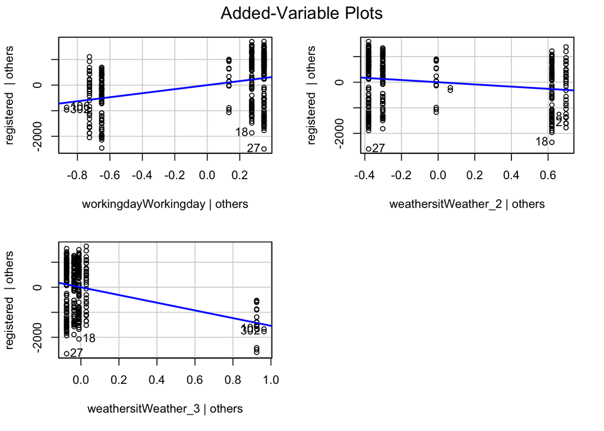

```r
#plot added variables
avPlots(full_model1)
```

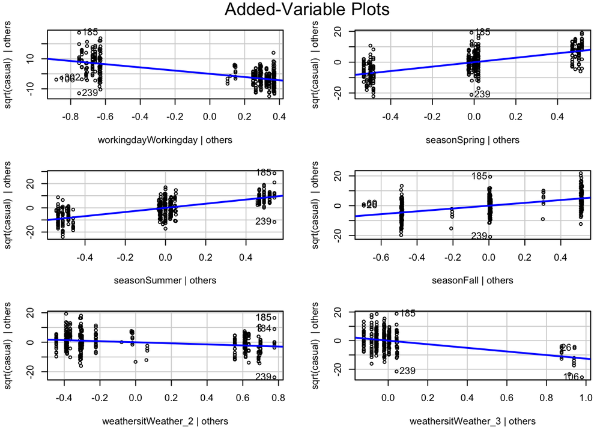

```r
avPlots(full_model2)
```

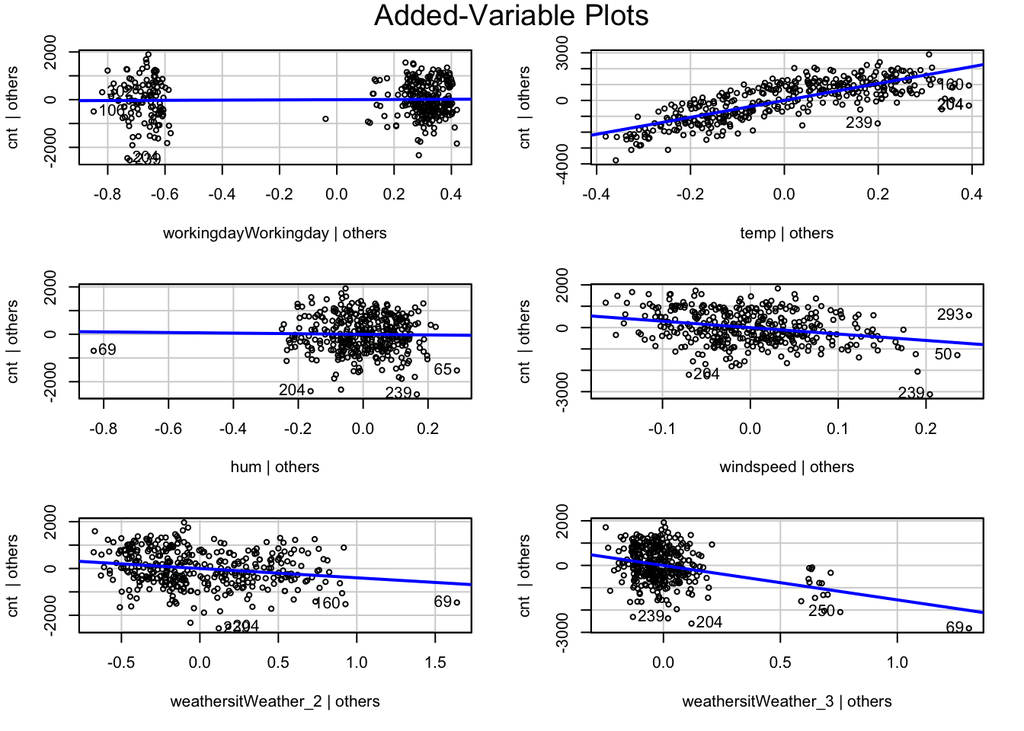

```r
avPlots(full_model3)
```

# Stepwise Regression

```r
stepwise_model1 <- step(full_model1, direction = "both")
```

```
## Start:  AIC=5011.11
## registered ~ workingday + weathersit
##
##              Df Sum of Sq       RSS    AIC
## <none>                    327513136 5011.1
## - weathersit  2  42004052 369517187 5051.2
## - workingday  1  48510926 376024062 5059.5
```

```r
stepwise_model2 <- step(full_model2, direction = "both")
```

```
## Start:  AIC=1302.89
## sqrt(casual) ~ workingday + season + weathersit
##
##              Df Sum of Sq   RSS    AIC
## <none>                    12470 1302.9
## - weathersit  2    2808.6 15279 1373.0
## - workingday  1    8892.0 21362 1497.4
## - season      3   15495.4 27966 1591.7
```

```r
stepwise_model3 <- step(full_model3, direction = "both")
```

```
## Start:  AIC=4859.41
## cnt ~ workingday + temp + hum + windspeed + weathersit
##
##              Df Sum of Sq       RSS    AIC
## - hum         1     74737 212691531 4857.5
## - workingday  1    163313 212780107 4857.7
## <none>                    212616794 4859.4
## - windspeed   1  16874286 229491080 4885.3
## - weathersit  2  26124379 238741173 4897.7
## - temp        1 344557701 557174495 5209.0
##
## Step:  AIC=4857.54
## cnt ~ workingday + temp + windspeed + weathersit
##
##              Df Sum of Sq       RSS    AIC
## - workingday  1    175352 212866883 4855.8
## <none>                    212691531 4857.5
## + hum         1     74737 212616794 4859.4
## - windspeed   1  18105352 230796883 4885.4
## - weathersit  2  42314793 255006324 4919.8
## - temp        1 360877574 573569105 5217.6
##
## Step:  AIC=4855.84
## cnt ~ temp + windspeed + weathersit
##
##              Df Sum of Sq       RSS    AIC
## <none>                    212866883 4855.8
## + workingday  1    175352 212691531 4857.5
## + hum         1     86776 212780107 4857.7
## - windspeed   1  18088627 230955510 4883.6
## - weathersit  2  42241032 255107915 4917.9
## - temp        1 362989012 575855895 5217.1
```

```r
summary(stepwise_model1)
```

```
##
## Call:
## lm(formula = registered ~ workingday + weathersit, data = training_data)
##
## Residuals:
##     Min      1Q  Median      3Q     Max
## -2770.6  -940.7   358.4   732.7  1680.3
##
## Coefficients:
##                      Estimate Std. Error t value Pr(>|t|)
## (Intercept)           2396.97      94.59  25.339  < 2e-16 ***
## workingdayWorkingday   789.66     107.99   7.312 1.71e-12 ***
## weathersitWeather_2   -430.29     106.76  -4.031 6.79e-05 ***
## weathersitWeather_3  -1540.07     255.03  -6.039 3.86e-09 ***
## ---
## Signif. codes:  0 '***' 0.001 '**' 0.01 '*' 0.05 '.' 0.1 ' ' 1
##
## Residual standard error: 952.5 on 361 degrees of freedom
## Multiple R-squared:  0.1994, Adjusted R-squared:  0.1927
## F-statistic: 29.97 on 3 and 361 DF,  p-value: < 2.2e-16
```

```r
summary(stepwise_model2)
```

```
##
## Call:
## lm(formula = sqrt(casual) ~ workingday + season + weathersit,
##     data = training_data)
##
## Residuals:
##      Min       1Q   Median       3Q      Max
## -20.9963  -3.5717   0.0082   3.6853  19.3328
##
## Coefficients:
##                      Estimate Std. Error t value Pr(>|t|)
## (Intercept)           22.5236     0.7917  28.449  < 2e-16 ***
## workingdayWorkingday -10.6997     0.6697 -15.977  < 2e-16 ***
## seasonSpring          14.3744     0.8760  16.409  < 2e-16 ***
## seasonSummer          17.1367     0.8728  19.633  < 2e-16 ***
## seasonFall             9.4982     0.8887  10.688  < 2e-16 ***
## weathersitWeather_2   -3.6307     0.6656  -5.455 9.18e-08 ***
## weathersitWeather_3  -12.5801     1.5961  -7.882 3.93e-14 ***
## ---
## Signif. codes:  0 '***' 0.001 '**' 0.01 '*' 0.05 '.' 0.1 ' ' 1
##
## Residual standard error: 5.902 on 358 degrees of freedom
## Multiple R-squared:  0.6925, Adjusted R-squared:  0.6873
## F-statistic: 134.4 on 6 and 358 DF,  p-value: < 2.2e-16
```

```r
summary(stepwise_model3)
```

```
##
## Call:
## lm(formula = cnt ~ temp + windspeed + weathersit, data = training_data)
##
## Residuals:
##      Min       1Q   Median       3Q      Max
## -2567.89  -514.98   -58.85   601.88  1903.93
##
## Coefficients:
##                     Estimate Std. Error t value Pr(>|t|)
## (Intercept)          1585.59     161.74   9.803  < 2e-16 ***
## temp                 5318.85     214.67  24.777  < 2e-16 ***
## windspeed           -2938.10     531.21  -5.531 6.13e-08 ***
## weathersitWeather_2  -415.92      86.29  -4.820 2.12e-06 ***
## weathersitWeather_3 -1573.53     206.70  -7.613 2.38e-13 ***
## ---
## Signif. codes:  0 '***' 0.001 '**' 0.01 '*' 0.05 '.' 0.1 ' ' 1
##
## Residual standard error: 769 on 360 degrees of freedom
## Multiple R-squared:  0.6924, Adjusted R-squared:  0.6889
## F-statistic: 202.6 on 4 and 360 DF,  p-value: < 2.2e-16
```

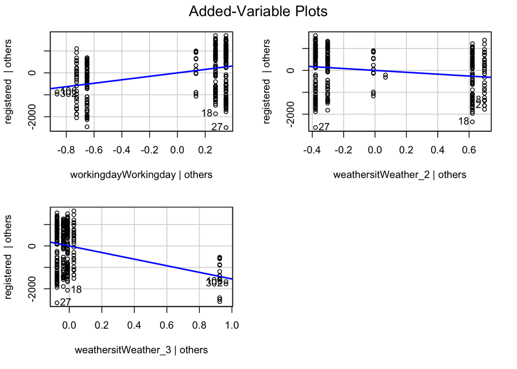

```r
avPlots(stepwise_model1)
```

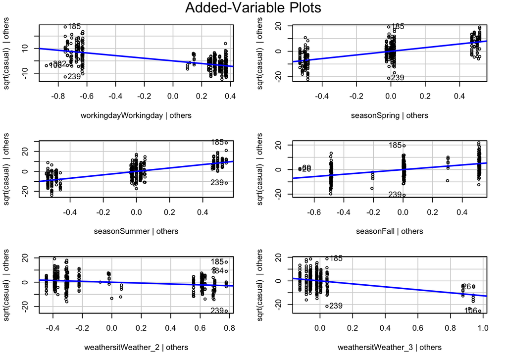

```r
avPlots(stepwise_model2)
```

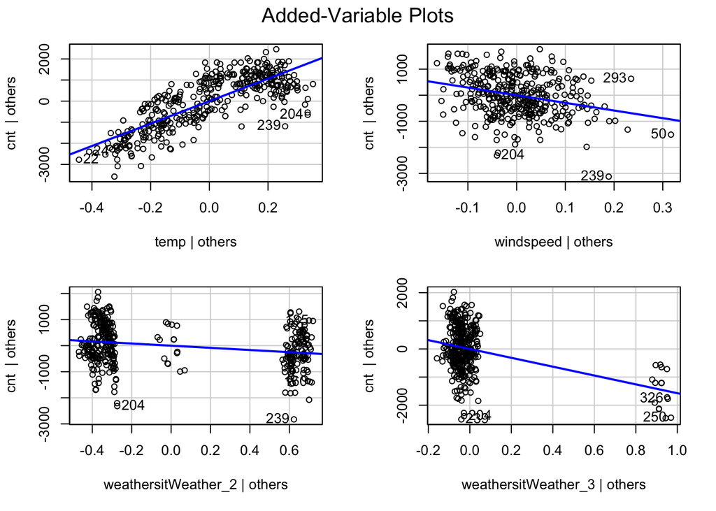

```r
avPlots(stepwise_model3)
```

For vif, values close to 1 indicate no multicollinearity, values between 1-2 indicate mild collinearity which is not ideal but can be considered ok since it won’t severaly impact the interpretability of the coefficients, values aboved 2 indicate severe multicollinearity which is considered unreliable.

```r
vif(stepwise_model1)
```

```
##                GVIF Df GVIF^(1/(2*Df))
## workingday 1.012487  1        1.006224
## weathersit 1.012487  2        1.003107
```

```r
vif(stepwise_model2)
```

```
##                GVIF Df GVIF^(1/(2*Df))
## workingday 1.014109  1        1.007030
## season     1.034514  3        1.005671
## weathersit 1.046385  2        1.011400
```

```r
vif(stepwise_model3)
```

```
##                GVIF Df GVIF^(1/(2*Df))
## temp       1.019765  1        1.009834
## windspeed  1.026996  1        1.013408
## weathersit 1.022105  2        1.005481
```

## Diagnostics

```r
# Create a data frame with the residuals and fitted values
```

### Prediction

```r
validation_data$predicted_registered <- predict(stepwise_model1, newdata = validation_data)
validation_data$predicted_sqrtcasual <- predict(stepwise_model2, newdata = validation_data)
validation_data$predicted_count <- predict(stepwise_model3, newdata = validation_data)
```

### Note: here in the predicitons I am unsure why the firts one is negative, in thesecond quetsion, I am unsure whether I should square the original value or not (not sure wthere it predicts the squared casaul count or not). In the third question, it produces Nans???

```r
observed_values1 <- validation_data$registered
predicted_values1 <- validation_data$predicted_registered
# Calculate different prediction performance metrics
# Functions from the MLmetrics package
# Common regression metrics
# Calculate the Root Mean Squared Error (RMSE), which measures the ...
# ... average magnitude of prediction errors.
# Lower is better.
rmse1 <- RMSE(predicted_values1, observed_values1)
# same as
# sqrt(mean((observed_values - predicted_values)^2))

# Compute the Mean Absolute Error (MAE), indicating the average absolute ...
# ... difference between predicted and observed values.
# Lower is better.
mae1 <- MAE(predicted_values1, observed_values1)
# same as
# mean(abs(observed_values - predicted_values))

# Calculate the Mean Absolute Percentage Error (MAPE), measuring the ...
# ... average percentage difference between predicted and observed values.
mape1 <- MAPE(predicted_values1, observed_values1)
# same as
# mean(abs(predicted_values-observed_values)/observed_values)

# Determine the R-squared (R²) Score, representing the proportion of the ...
# ... variance in the observed values (of validation data set) ...
# ... explained by the predicted values from the model.
# Higher is better.
r_squared1 <- R2_Score(predicted_values1, observed_values1)
# same as
# summary(lm(observed_values ~ predicted_values))$r.squared

# Display the calculated metrics
cat("Root Mean Squared Error (RMSE):", round(rmse1, digits = 4), "\n")
```

```
## Root Mean Squared Error (RMSE): 2192.873
```

```r
cat("Mean Absolute Error (MAE):", round(mae1, digits = 4), "\n")
```

```
## Mean Absolute Error (MAE): 1951.641
```

```r
cat("R-squared (R^2) Score:", round(r_squared1, digits = 4), "\n")
```

```
## R-squared (R^2) Score: -1.3768
```

```r
cat("Mean Absolute Percentage Error (MPE):", round(mape1, digits = 4), "\n")
```

```
## Mean Absolute Percentage Error (MPE): 0.6417
```

```r
#second question

observed_values2 <- sqrt(validation_data$casual) #should I transform it here??
predicted_values2 <- validation_data$predicted_sqrtcasual
rmse2 <- RMSE(predicted_values2, observed_values2)
mae2 <- MAE(predicted_values2, observed_values2)
mape2 <- MAPE(predicted_values2, observed_values2)
r_squared2 <- R2_Score(predicted_values2, observed_values2)
cat("Root Mean Squared Error (RMSE):", round(rmse2, digits = 4), "\n")
```

```
## Root Mean Squared Error (RMSE): 8.9667
```

```r
cat("Mean Absolute Error (MAE):", round(mae2, digits = 4), "\n")
```

```
## Mean Absolute Error (MAE): 6.9653
```

```r
cat("R-squared (R^2) Score:", round(r_squared2, digits = 4), "\n")
```

```
## R-squared (R^2) Score: 0.4235
```

```r
cat("Mean Absolute Percentage Error (MPE):", round(mape2, digits = 4), "\n")
```

```
## Mean Absolute Percentage Error (MPE): 0.2525
```

```r
#third question
observed_values3 <- validation_data$count
predicted_values3 <- validation_data$predicted_count
rmse3 <- RMSE(predicted_values3, observed_values3)
mae3 <- MAE(predicted_values3, observed_values3)
mape3 <- MAPE(predicted_values3, observed_values3)
r_squared3 <- R2_Score(predicted_values3, observed_values3)
cat("Root Mean Squared Error (RMSE):", round(rmse3, digits = 4), "\n")
```

```
## Root Mean Squared Error (RMSE): NaN
```

```r
cat("Mean Absolute Error (MAE):", round(mae3, digits = 4), "\n")
```

```
## Mean Absolute Error (MAE): NaN
```

```r
cat("R-squared (R^2) Score:", round(r_squared3, digits = 4), "\n")
```

```
## R-squared (R^2) Score: NaN
```

```r
cat("Mean Absolute Percentage Error (MPE):", round(mape3, digits = 4), "\n")
```

```
## Mean Absolute Percentage Error (MPE): NaN
```